# Assessment of the Effect of Global Warming on Phytoplankton Biomass in Coastal Waters of Tanzania

Nyamisi Peter (2016-07-00335)

Supervisors: Prof. C. Lugomela & Dr. M. Kyewalyanga

2024-01-26

## Layout

- Chapter 1: Introduction
- Chapter 2: Data types and Methodologies
- Chapter 3: Global warming
- Chapter 4: Phytoplankton biomass and global warming indices
- Chapter 5: Vertical distribution of phytoplankton biomass
- Chapter 6: Conclusion & recommendation
- Appendices: Published articles
- Appendices: Creativity and Innovations

# CHAPTER ONE INTRODUCTION

## Phytoplankton

- Microscopic aquatic plants
- Possess Chl-a
- Primary producers
- Passive swimmers — Aided by water movement

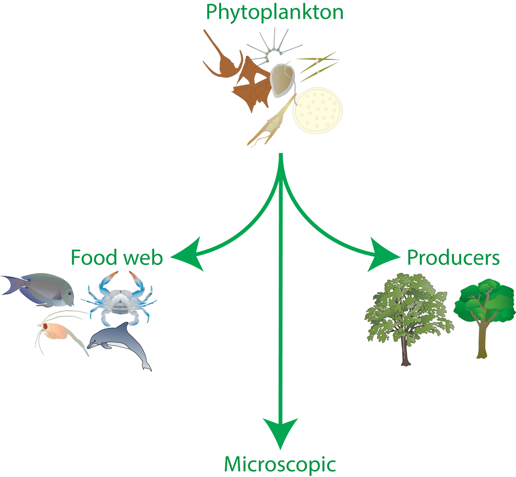

## Importance of phyto.

- Contribute nearly half of the total annual global primary production (Boyce et al., 2014)
- Influence global climate (Murtugudde et al., 2002)
- Influence biogeochemical cycle - uptake of carbon (Sabine et al., 2004)

**Warning**

Changes in phytoplankton affect ocean food web, marine ecosystems, biogeochemical cycle

## Global warming

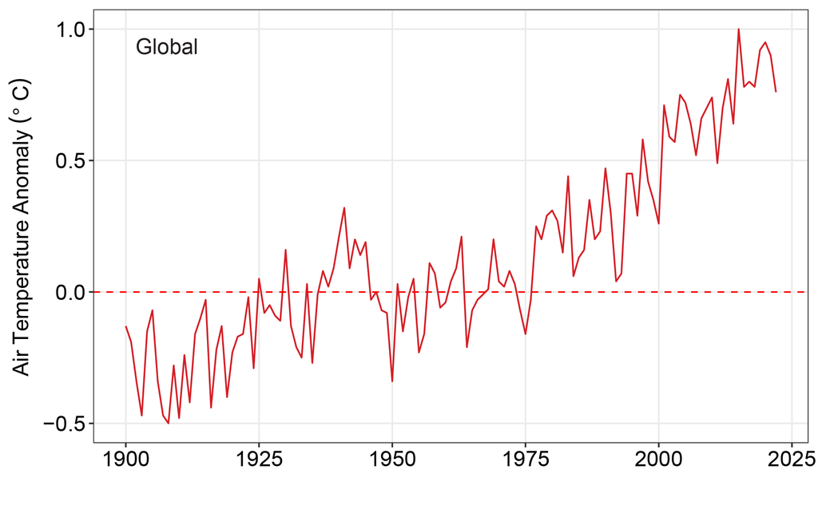

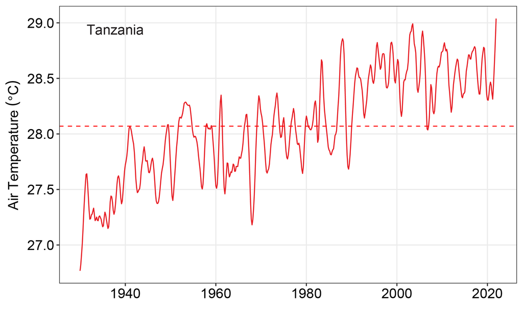

## Problem statement

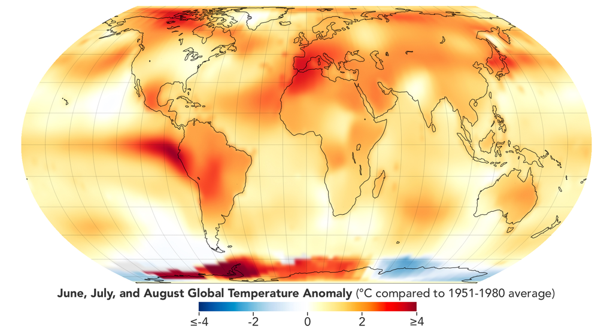

- Limited information on the effects of global warming on phytoplankton
- Lack of long-term data
- Past studies used short-term data
- Most phytoplankton information are of the surface water

## Significance of the study

- Influence of global warming on phytoplankton biomass
- Accessibility of long-term data
- Determine phytoplankton biomass across the water column

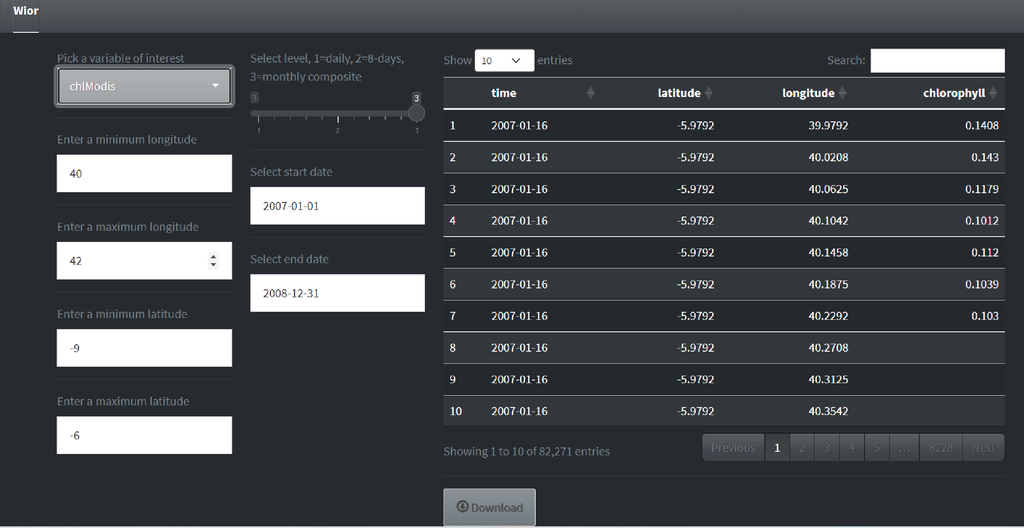

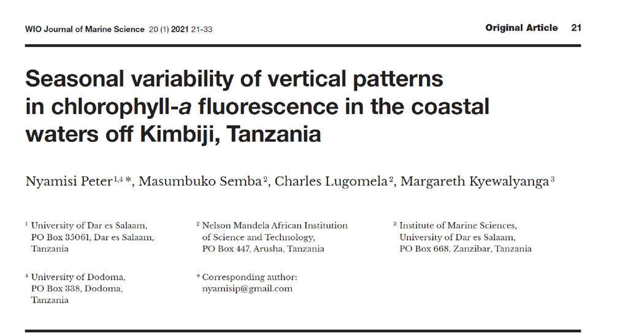

## Research Objectives

1. To assess the influence of global warming on SST around coastal waters in Tanzania
2. To determine changes in phytoplankton biomass (Chl-*a*) and SST over a period of 18 years in coastal waters of Tanzania
3. To assess the vertical distribution of phytoplankton biomass
4. To determine changes in temperature, precipitation and river discharge on phytoplankton biomass

# CHAPTER TWO DATA TYPES AND METHODOLOGIES

## Study location

Coastal waters of Tanzania, with focus in key areas:

- Pemba Channel
- Zanzibar Channel
- Mafia Channel
- Mtwara site

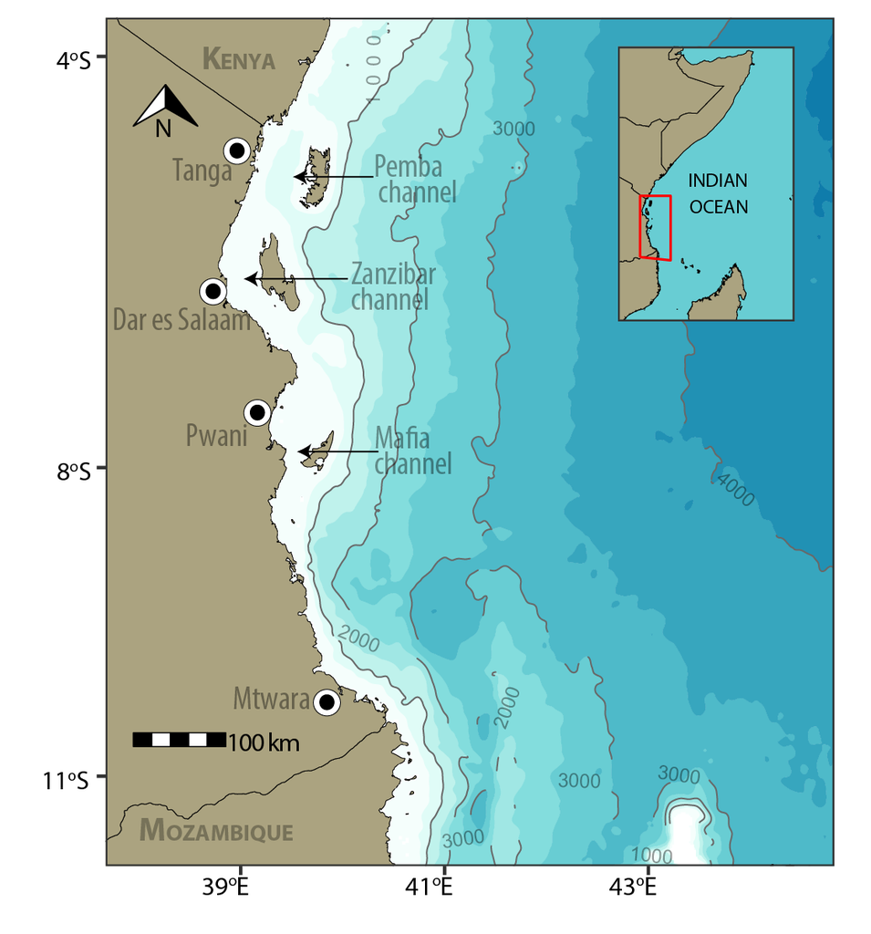

## Data Types & Acquisition

1. Satellite data-Chla & SST
- MODIS sensor
- Spatial–4km
- Monthly composite
- 2003–2020

```r
chl = wior::get_chlModis(
                   lon.min = 38.837,
                   lon.max = 39.787,
                   lat.min = -5.605,
                   lat.max = -4.598,
                   t1 = "2003-01-01",
                   t2 = "2020-12-31",
                   level = 3)
```

```r
sst = wior::get_sstMODIS(
                   lon.min = 39.666,
                   lon.max = 39.683,
                   lat.min = -6.812,
                   lat.max = -5.627,
                   t1 = "2003-01-01",
                   t2 = "2020-12-31",
                   level = 3)
```

## Data Types & Acquisition…

2. Satellite data-Precipitation
- Spatial–6km
- Monthly composite
- 2003–2020
- [Climate Hazards Group InfraRed Precipitation with Station data (CHIRPS)](https://www.chc.ucsb.edu/data/chirps)

```r
rain = wior::get_rainLand(
                   lon.min = 38.837,
                   lon.max = 39.787,
                   lat.min = -5.605,
                   lat.max = -4.598,
                   t1 = "2003-01-01",
                   t2 = "2020-12-31",
                   level = 3)
```

## Data Types & Acquisition…

3. Hydrographic Data Conductivity Temperature Depth (CTD)
- IIOE-2 Cruise – 2017 & 2018
- Algoa cruise – 2004

```r
ne.files = dir(".", pattern = ".cnv", full.names = TRUE)

ctd.ne=list()

for (i in 1:length(ne.files)){

  ctd.ne[[i]]=read.ctd(ne.files[[i]])%>%
    ctdDecimate(p = 10)
  ctd.ne[[i]]@metadata$scientist = "Nyamisi Peter"
  ctd.ne[[i]]@metadata$institute = "University of Dar es Salaam"
  ctd.ne[[i]]@metadata$address = "P.O BOX 60091, Dar es Salaam"

}
```

## Data Types & Acquisition…

4. Air temperature
- TMA
- Sites — Tanga, Dar es Salaam, Pwani, Mtwara
- 1997 – 2017
- Monthly average

```r
sheets = readxl::excel_sheets("../data/air_temp_tma.xlsx")

temp.dat = list()

for (i in 1:length(sheets)) {

temp.dat[[i]] = readxl::read_excel("../data/air_temp_tma.xlsx",
                                   sheet = sheets[i]) %>%
  janitor::clean_names()%>%
  pivot_longer(cols = 2:13, names_to = "month", values_to = "temp") %>%
  filter(years < 2018)%>%
  mutate(site = sheets[i],
         date = seq(dmy(01011997), dmy(01122017), by = "month")) %>%
  select(date, temp, site) %>%
  mutate_if(is.numeric, round, 3)
}

temp.data = bind_rows(temp.dat)
```

## Data Types & Acquisition…

5. River discharge
- Ministry of Water
- Sites — Pangani (Pemba Channel), Ruvu (Zanzibar Channel), Rufiji (Mafia Channel), Ruvuma (Mtwara site)
- Daily
- 2010 – 2020

```r
years = 2010:2020

stiegler = tabulizer::extract_tables(file = pdf.file,
                                     pages = 288:289,
                                     guess = TRUE,
                                     method = "stream")

stiegler.tb = list()

for (i in 1:length(years)){

stiegler.df = muhiga[[i]] %>%
  as.data.frame()

if (ncol(stiegler.df) != 14) next

stiegler.df = stiegler.df %>%
  dplyr::select(2:14) %>%
  slice(1:31)


names(stiegler.df) = var.names

stiegler.tb[[i]] = stiegler.df %>%
  mutate(lon = "7:48:24",
         lat ="37:53:44" ,
         station = "stiegler",
         year = years[i]) %>%
  separate(lon, into = c("lon", "min", "sec"),
           sep = ":",
           convert = TRUE) %>%
  mutate(lon = lon+min/60+sec/3600) %>%
  separate(lat, into = c("lat", "min", "sec"),
           sep = ":",
           convert = TRUE) %>%
  mutate(river = "Rufiji",
         lat = (lat+min/60+sec/3600)*-1) %>%
  dplyr::select(-c(min, sec)) %>%
  relocate(c(river, station, lon,lat, year), .before = day) %>%
  pivot_longer(cols = Jan:Dec,
               names_to = "months",
               values_to = "flow") %>%
  mutate(flow = flow %>% as.numeric(),
         month.integer = rep(1:12, times = 31))

}

stiegler.tb = stiegler.tb %>% bind_rows()

stiegler.tb %>%
  group_by(months) %>%
  summarise(bar = mean(flow, na.rm = TRUE))
```

## Data Processing & Analysis

- Data were structured and organized in R (R Core Team, 2022)
- Annual trends were analysed using Mann-Kendall trend test
- Seasonal differences were tested using Wilcoxon rank sum test
- General Additive Model (GAM) was used to assess the influence of global warming on phytoplankton biomass

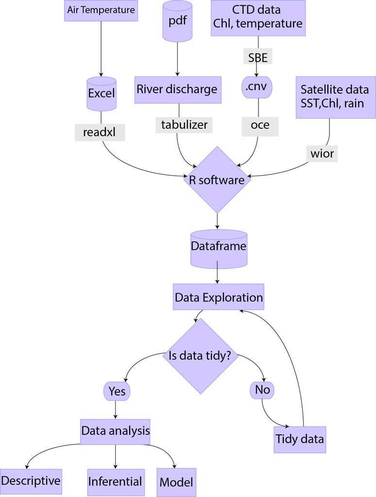

# CHAPTER THREE AIR TEMPERATURE AND SST

## Air temperature Trend

- All sites have positive increasing trends
- Zanzibar has the highest increase rate
- Pemba has the lowest increase rate
- The increasing trends were significant (z > 1.96, p < 0.05)

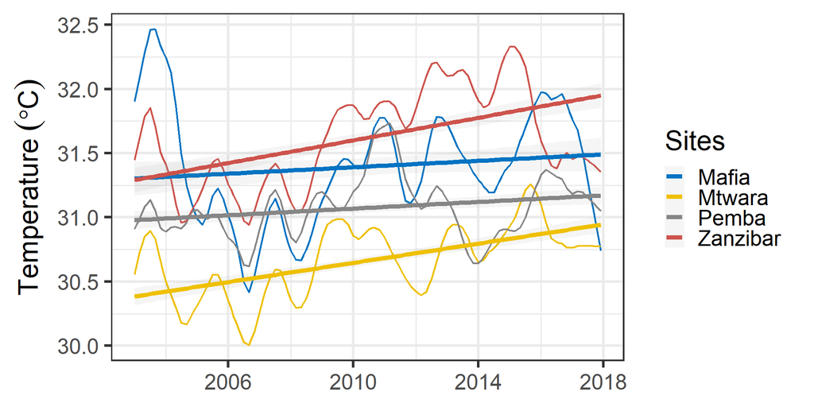

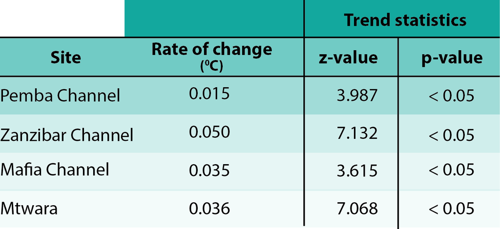

## SST Trend

- All sites have positive increasing trends
- Mtwara has the highest increase rate
- Zanzibar has the lowest increase rate
- The increasing trends were significant (z > 1.96, p < 0.05)

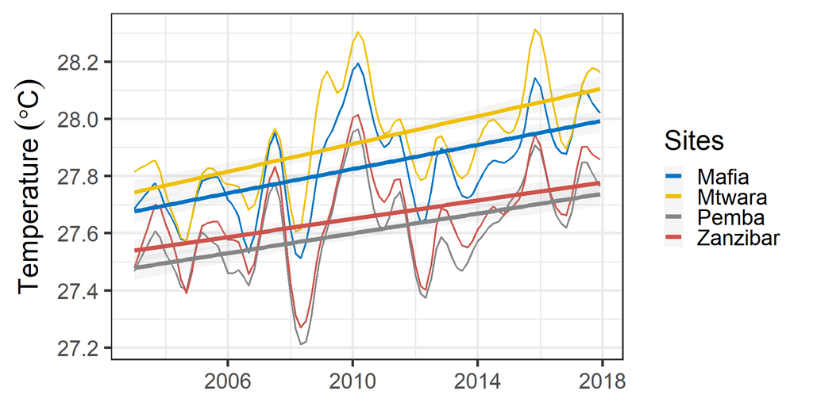

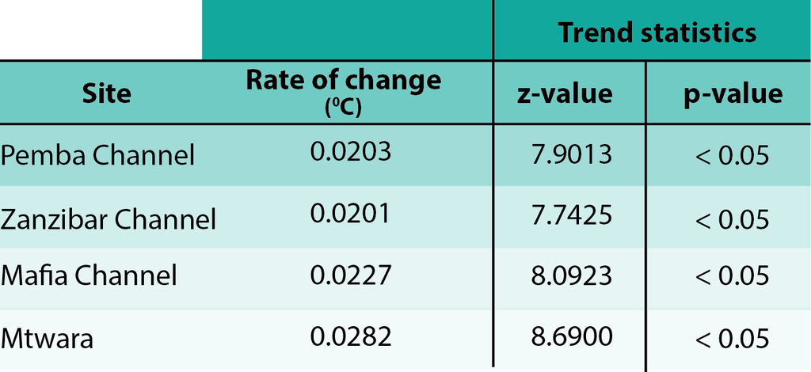

# CHAPTER FOUR PHYTOPLANKTON BIOMASS AND GLOBAL WARMING INDICES

## Chl-a & SST Variation

- Chl-a and SST have monthly variation
- High Chl-a occurs May to September
- Low SST occurs June to September
- Inverse relationship between SST and Chl-a

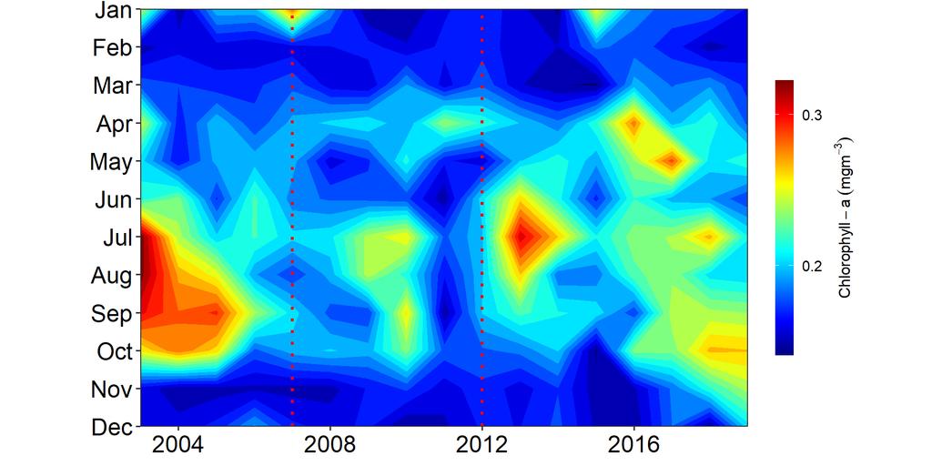

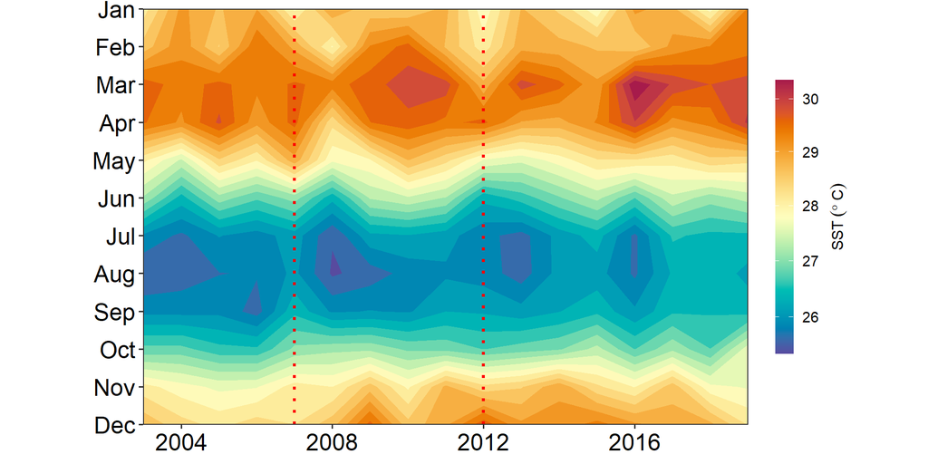

## Annual trend in Chl-a

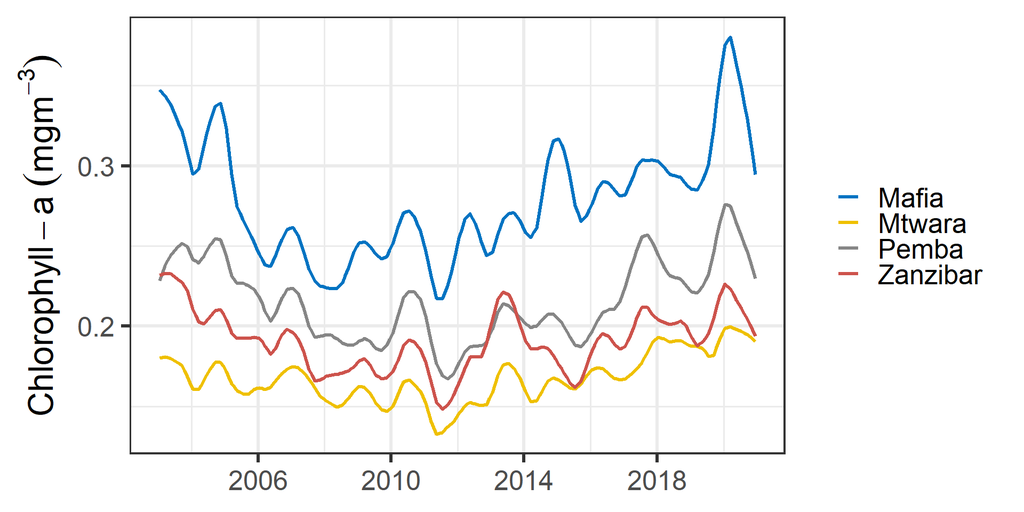

- Positive increase trend but only Mafia and Mtwara are significant

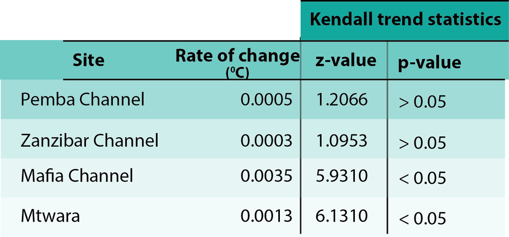

## SST Trend

- Mtwara has the highest and Zanzibar has the lowest increasing trend

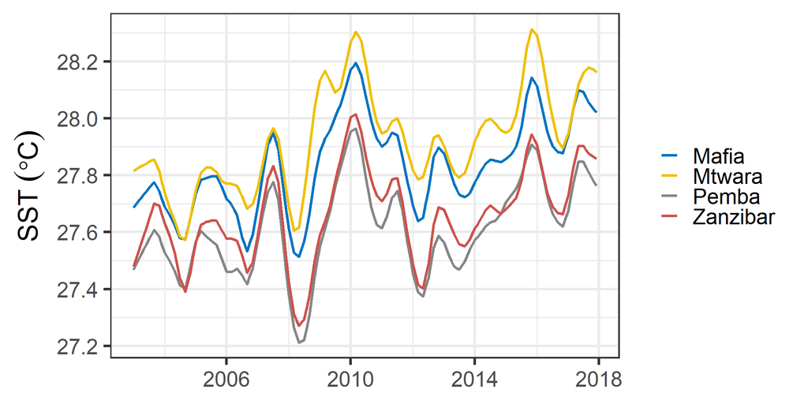

- Positive increase trend and significant

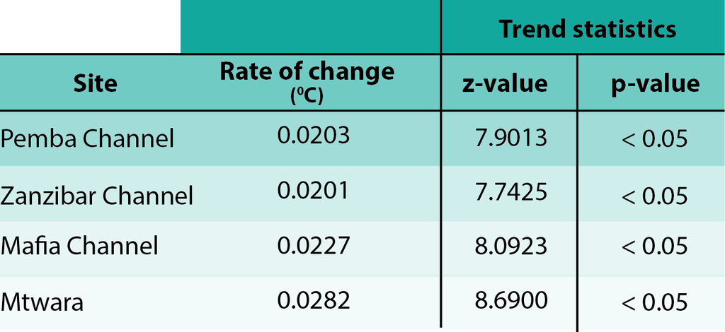

## GAM–global warming indices

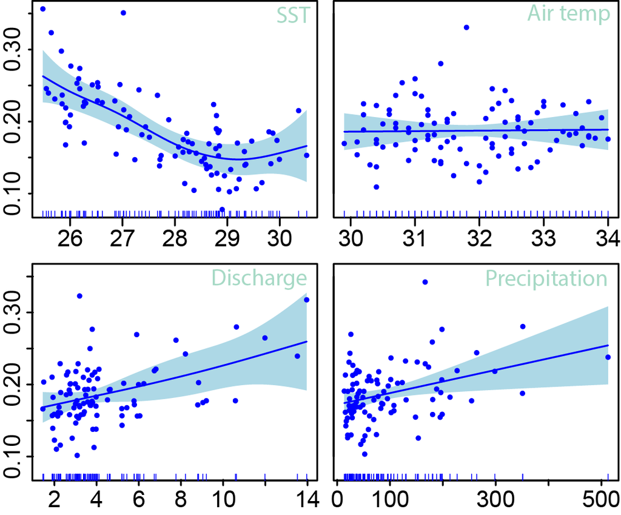

# CHAPTER FIVE VERTICAL DISTRIBUTION OF PHYTOPLANKTON BIOMASS

## Vertical variation in Chl-a

- Most studies available focused on surface water
- Limited information of Chl-a in water column
- Subsurface chlorophyll maximum (SCM) information is lacking
- This study established depth at which SCM is found

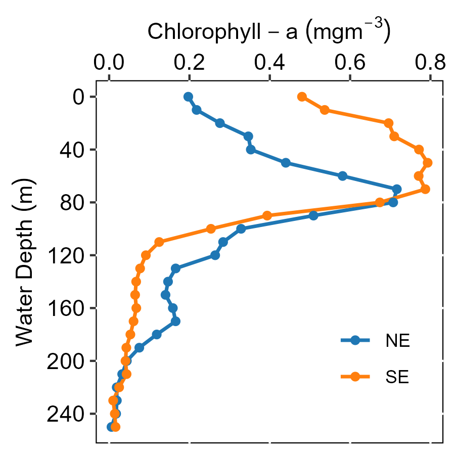

## Vertical Chl-a cross-section

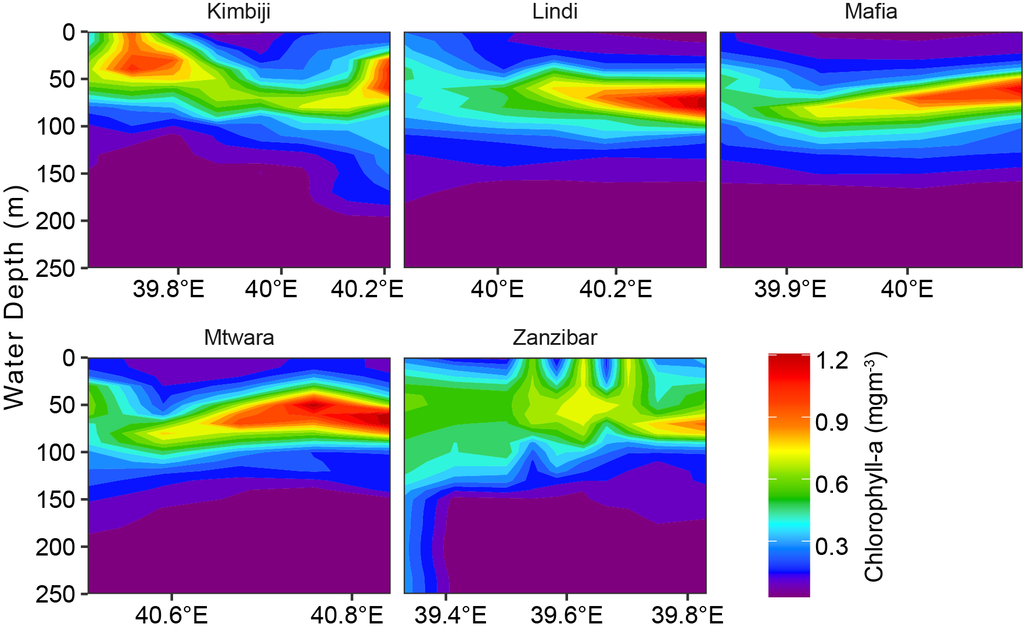

## Depth at SCM

- Occurs at shallower depth in SE & deeper in NE

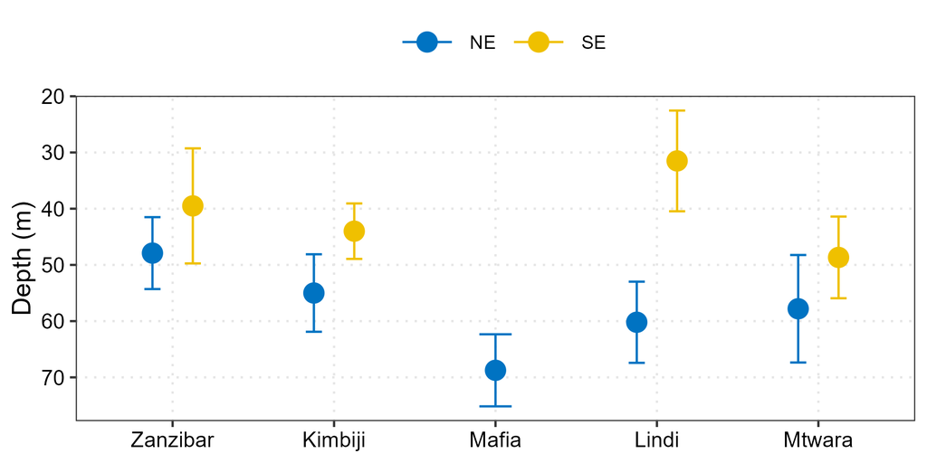

## Chl-a at SCM

- SE has higher concentration than NE

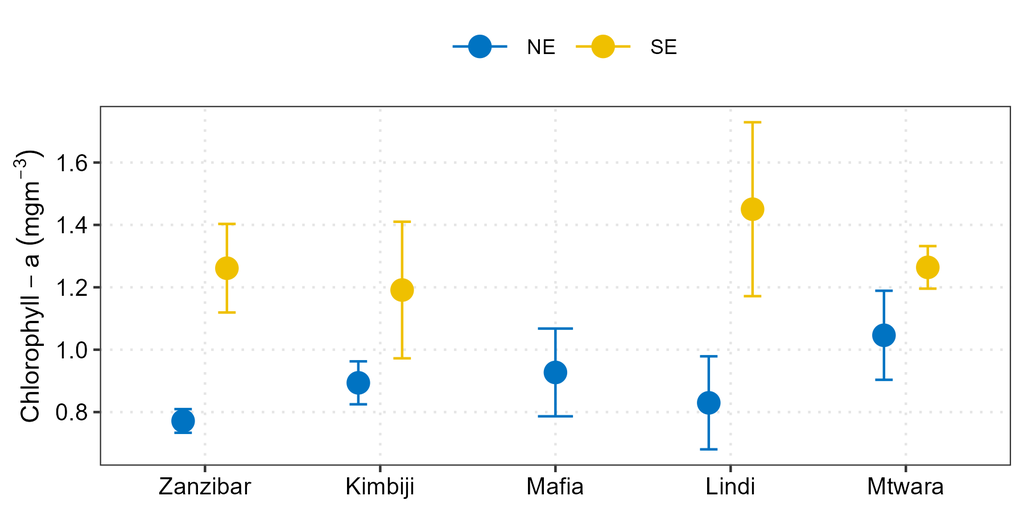

## Seasonal Chl-a profile

- SCM has significant higher Chl-a than surface during NE and SE
- SCM has twice Chl-a value compared to surface

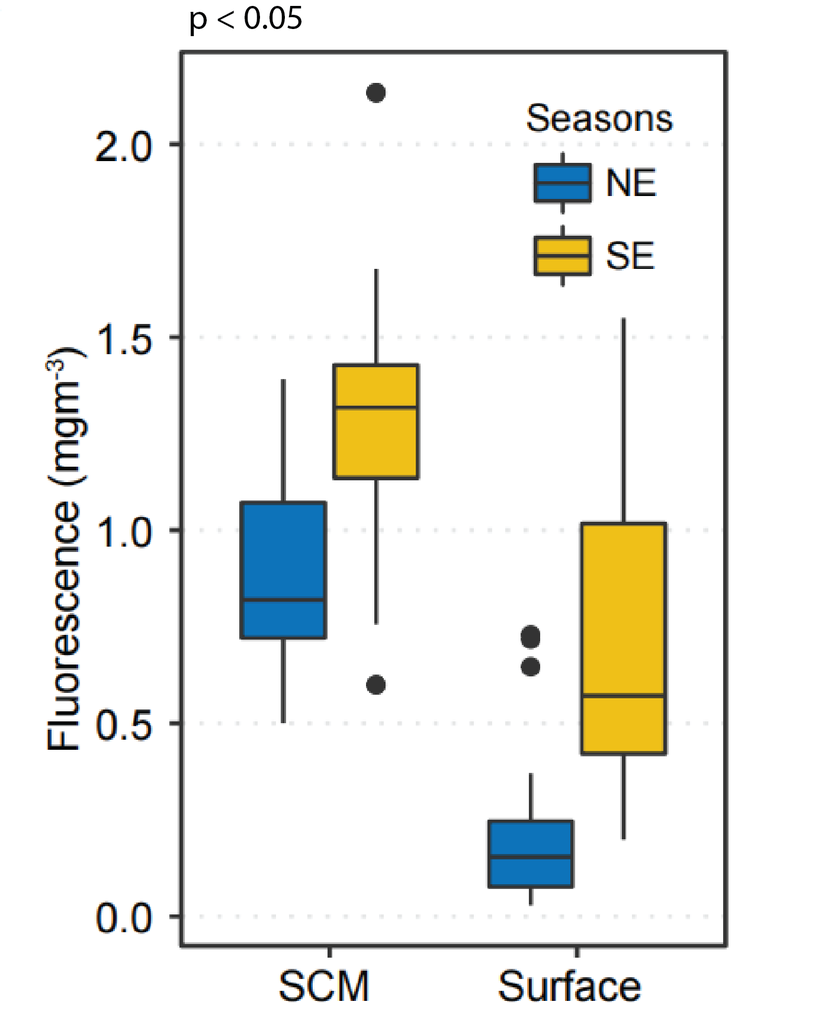

# CHAPTER SIX CONCLUSION & RECOMMENDATIONS

## Conclusion & Recommendations

**Conclusions**

**Recommendations**

1. More studies on modelling and predictions of future trend of phytoplankton
2. Good agricultural practices in coastal areas to reduce nutrient load
3. Continuous monitoring of hydrographic profile
4. Explore the relationship between the trend of phytoplankton biomass and fish catch

# Appendices

# Tools developed

## Tools & App

**Wior package**

- Available at GitHub (https://github.com/lugoga/wior)

[figure not shown]

**Wior webApp**

- Available at (https://nyamisi.shinyapps.io/NyamisiApplication/)

[figure not shown]

## Wior webApp

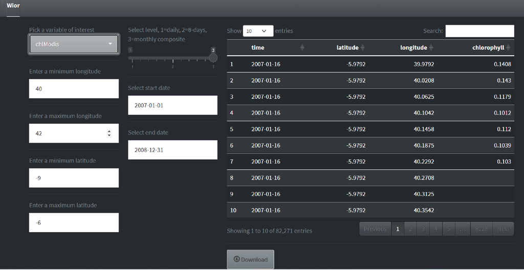

## Acknowledgement

[figure not shown]

# THANK YOU FOR LISTENING

## SCAN TO ACCESS THE PRESENTATION

[figure not shown]

## SCAN TO ACCESS THE PRESENTATION

[figure not shown]

## References

Boyce, D.G., Dowd, M., Lewis, M.R., Worm, B., 2014. Estimating global chlorophyll changes over the past century. Progress in Oceanography 122, 163–173. https://doi.org/10.1016/j.pocean.2014.01.004

IPCC, 2013. Intergovernmental panel on climate change, 2014. Working Group I Contribution to the IPCC Fifth Assessment Report. Climate Change 8.

Murtugudde, R., Beauchamp, J., McClain, C.R., Lewis, M., Busalacchi, A.J., 2002. Effects of penetrative radiation on the upper tropical ocean circulation. Journal of Climate 15, 470–486.

R Core Team, 2022. [R: A language and environment for statistical computing](https://www.R-project.org/). R Foundation for Statistical Computing, Vienna, Austria.

Sabine, C.L., Feely, R.A., Gruber, N., Key, R.M., Lee, K., Bullister, J.L., Wanninkhof, R., Wong, C., Wallace, D.W., Tilbrook, B., others, 2004. The oceanic sink for anthropogenic CO2. science 305, 367–371.

Solomon, S., Qin, D., Manning, M., Averyt, K., Marquis, M., 2007. Climate change 2007-the physical science basis: Working group i contribution to the fourth assessment report of the IPCC. Cambridge university press.